# Weight-lifting classification

```r
library(caret)
```

Load the data.

```r
training <- read.csv("pml-training.csv", na.string=c("NA", ""))
```

I first explore the NA values. The goal is to determine what percent of each column is NA.

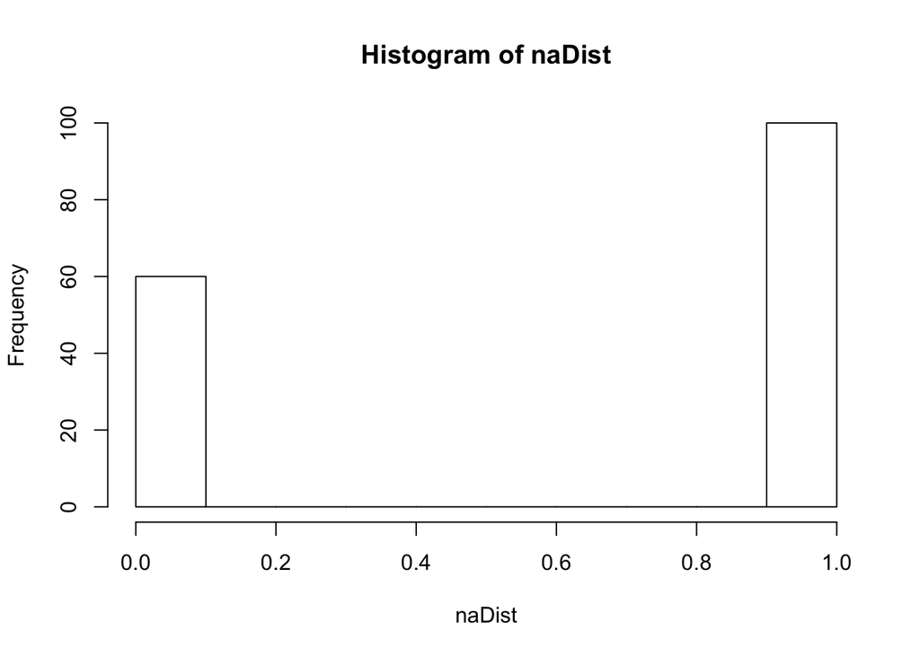

```r
naDist <- numeric()
for(i in 1:dim(training)[2]){
        naDist <- c(naDist, sum(is.na(training[,i]))/dim(training)[1])
}
hist(naDist)
```

There appear to be quite a few columns with nearly all NA values, so those are removed. If those are critical to classe determination then training will fail and I can return to potential pattersn in the NA values. While cleaning the data, also remove variables that are near zero variance or will not generalize based on their definition.

```r
training <- training[,-c(1:5)] ## remove columns w/data that will not generalize
remove <- numeric()
for(i in 1:dim(training)[2]){
        if(sum(is.na(training[,i])) > 0.96*dim(training)[1])
        {
                remove <- c(remove, i)
        }
}
training <- training[,-remove] #remove columns with >96% NA values
nzv <- nearZeroVar(training)
nzv
```

```
## [1] 1
```

```r
training <- training[,-as.numeric(nzv)]
```

To better estimate out of sample error, set aside 20% of the training data as a test set (in this case leaving “pml_test.csv” as a validation/quiz set).

```r
set.seed(12345)
inTrain <- createDataPartition(training$classe, p=0.8, list=F)
training.final <- training[inTrain,]
testing <- training[-inTrain,]
```

Let’s try one relatively simple and fast algorithm (k nearest neighbors) and one potentially more accurate but time consuming algorithm (the default gradient boosted model from caret). In both cases, let’s use 10-fold cross validation to estimate the accuracy on the training set and give a somewhat optimisic assessment of out of sample error .

```r
startTimeFullKNN <- Sys.time()
trainCtrl <- trainControl(method="cv", number=10) ## Use 10-Fold CROSS VALIDATION
modKNN <- train(classe ~ ., data=training.final, preProcess=c("center", "scale"), trControl = trainCtrl, method="knn")
endTimeFullKNN <- Sys.time()
endTimeFullKNN - startTimeFullKNN
```

```
## Time difference of 2.191395 mins
```

```r
modKNN$finalModel
```

```
## 5-nearest neighbor classification model
##
## Call:
## knn3.matrix(x = as.matrix(x), y = y, k = param$k)
##
## Training set class distribution:
##
##    A    B    C    D    E
## 4464 3038 2738 2573 2886
```

```r
trainPreds <- predict(modKNN, training.final)
confusionMatrix(trainPreds, reference=training.final$classe)
```

```
## Confusion Matrix and Statistics
##
##           Reference
## Prediction    A    B    C    D    E
##          A 4453   27    1    3    0
##          B    5 2983   14    1    5
##          C    2   26 2706   41    7
##          D    3    1   13 2522    6
##          E    1    1    4    6 2868
##
## Overall Statistics
##
##                Accuracy : 0.9894
##                  95% CI : (0.9876, 0.9909)
##     No Information Rate : 0.2843
##     P-Value [Acc > NIR] : < 2.2e-16
##
##                   Kappa : 0.9865
##  Mcnemar's Test P-Value : 3.702e-05
##
## Statistics by Class:
##
##                      Class: A Class: B Class: C Class: D Class: E
## Sensitivity            0.9975   0.9819   0.9883   0.9802   0.9938
## Specificity            0.9972   0.9980   0.9941   0.9982   0.9991
## Pos Pred Value         0.9931   0.9917   0.9727   0.9910   0.9958
## Neg Pred Value         0.9990   0.9957   0.9975   0.9961   0.9986
## Prevalence             0.2843   0.1935   0.1744   0.1639   0.1838
## Detection Rate         0.2836   0.1900   0.1724   0.1606   0.1827
## Detection Prevalence   0.2856   0.1916   0.1772   0.1621   0.1835
## Balanced Accuracy      0.9974   0.9900   0.9912   0.9892   0.9964
```

```r
startTimeFullGBM <- Sys.time()
trainCtrl <- trainControl(method="cv", number=10) ## Use 10-Fold CROSS VALIDATION
modGBM <- train(classe ~ ., data=training.final, preProcess=c("center", "scale"), trControl = trainCtrl, method="gbm", verbose=F)
endTimeFullGBM <- Sys.time()
endTimeFullGBM - startTimeFullGBM
```

```
## Time difference of 9.661918 mins
```

```r
modGBM$finalModel
```

```
## A gradient boosted model with multinomial loss function.
## 150 iterations were performed.
## There were 53 predictors of which 44 had non-zero influence.
```

```r
trainPredsGBM <- predict(modGBM, training.final)
confusionMatrix(trainPredsGBM, reference=training.final$classe)
```

```
## Confusion Matrix and Statistics
##
##           Reference
## Prediction    A    B    C    D    E
##          A 4459   15    0    0    0
##          B    5 3009   10    5    7
##          C    0   14 2725   22    3
##          D    0    0    1 2545   17
##          E    0    0    2    1 2859
##
## Overall Statistics
##
##                Accuracy : 0.9935
##                  95% CI : (0.9921, 0.9947)
##     No Information Rate : 0.2843
##     P-Value [Acc > NIR] : < 2.2e-16
##
##                   Kappa : 0.9918
##  Mcnemar's Test P-Value : NA
##
## Statistics by Class:
##
##                      Class: A Class: B Class: C Class: D Class: E
## Sensitivity            0.9989   0.9905   0.9953   0.9891   0.9906
## Specificity            0.9987   0.9979   0.9970   0.9986   0.9998
## Pos Pred Value         0.9966   0.9911   0.9859   0.9930   0.9990
## Neg Pred Value         0.9996   0.9977   0.9990   0.9979   0.9979
## Prevalence             0.2843   0.1935   0.1744   0.1639   0.1838
## Detection Rate         0.2840   0.1917   0.1736   0.1621   0.1821
## Detection Prevalence   0.2850   0.1934   0.1761   0.1633   0.1823
## Balanced Accuracy      0.9988   0.9942   0.9961   0.9939   0.9952
```

Now let’s see how these two algorithms perform on the test set. This provides a better estimate of the out of sample error again based on 10-fold cross-validation.

```r
confusionMatrix(predict(modKNN, testing), testing$classe)
```

```
## Confusion Matrix and Statistics
##
##           Reference
## Prediction    A    B    C    D    E
##          A 1108   13    0    1    0
##          B    5  722    7    0    2
##          C    2   20  670   25    4
##          D    1    2    6  615    5
##          E    0    2    1    2  710
##
## Overall Statistics
##
##                Accuracy : 0.975
##                  95% CI : (0.9696, 0.9797)
##     No Information Rate : 0.2845
##     P-Value [Acc > NIR] : < 2.2e-16
##
##                   Kappa : 0.9684
##  Mcnemar's Test P-Value : NA
##
## Statistics by Class:
##
##                      Class: A Class: B Class: C Class: D Class: E
## Sensitivity            0.9928   0.9513   0.9795   0.9565   0.9847
## Specificity            0.9950   0.9956   0.9843   0.9957   0.9984
## Pos Pred Value         0.9875   0.9810   0.9293   0.9777   0.9930
## Neg Pred Value         0.9971   0.9884   0.9956   0.9915   0.9966
## Prevalence             0.2845   0.1935   0.1744   0.1639   0.1838
## Detection Rate         0.2824   0.1840   0.1708   0.1568   0.1810
## Detection Prevalence   0.2860   0.1876   0.1838   0.1603   0.1823
## Balanced Accuracy      0.9939   0.9734   0.9819   0.9761   0.9916
```

```r
confusionMatrix(predict(modGBM, testing), testing$classe)
```

```
## Confusion Matrix and Statistics
##
##           Reference
## Prediction    A    B    C    D    E
##          A 1115    8    0    0    0
##          B    0  745   10    2    3
##          C    0    6  672    7    0
##          D    0    0    2  633    5
##          E    1    0    0    1  713
##
## Overall Statistics
##
##                Accuracy : 0.9885
##                  95% CI : (0.9847, 0.9916)
##     No Information Rate : 0.2845
##     P-Value [Acc > NIR] : < 2.2e-16
##
##                   Kappa : 0.9855
##  Mcnemar's Test P-Value : NA
##
## Statistics by Class:
##
##                      Class: A Class: B Class: C Class: D Class: E
## Sensitivity            0.9991   0.9816   0.9825   0.9844   0.9889
## Specificity            0.9971   0.9953   0.9960   0.9979   0.9994
## Pos Pred Value         0.9929   0.9803   0.9810   0.9891   0.9972
## Neg Pred Value         0.9996   0.9956   0.9963   0.9970   0.9975
## Prevalence             0.2845   0.1935   0.1744   0.1639   0.1838
## Detection Rate         0.2842   0.1899   0.1713   0.1614   0.1817
## Detection Prevalence   0.2863   0.1937   0.1746   0.1631   0.1823
## Balanced Accuracy      0.9981   0.9884   0.9892   0.9912   0.9941
```

The GBM model performs slightly better with an estimated error of 0.84-1.53% (95% CI) compared to 2.03-3.04% (95% CI) for the KNN model (based on 10-fold cross validation in both cases).

Given these results the GBM model will be applied to the quiz/validation set.